# Analyse du dataset Titanic

Sylvain Mierzchala

2026-11-12

## 1. Chargement des données

```r
# install.packages("carData")  # à lancer une seule fois si besoin
library(carData)
data("TitanicSurvival")
```

## 2. Présentation des données

Le jeu de données `TitanicSurvival` (package `carData`) décrit le sort de 1309 passagers du Titanic, naufragé en avril 1912. Il contient 4 variables :

- **survived** : le passager a-t-il survécu ? (facteur : `no` / `yes`)
- **sex** : sexe du passager (facteur : `female` / `male`)
- **age** : âge en années (numérique, avec des valeurs manquantes ; certains enfants ont un âge fractionnaire)
- **passengerClass** : classe du billet (facteur : `1st`, `2nd`, `3rd`)

```r
head(TitanicSurvival)
```

```
##                                 survived    sex     age passengerClass
## Allen, Miss. Elisabeth Walton        yes female 29.0000            1st
## Allison, Master. Hudson Trevor       yes   male  0.9167            1st
## Allison, Miss. Helen Loraine          no female  2.0000            1st
## Allison, Mr. Hudson Joshua Crei       no   male 30.0000            1st
## Allison, Mrs. Hudson J C (Bessi       no female 25.0000            1st
## Anderson, Mr. Harry                  yes   male 48.0000            1st
```

```r
str(TitanicSurvival)
```

```
## 'data.frame':    1309 obs. of  4 variables:
##  $ survived      : Factor w/ 2 levels "no","yes": 2 2 1 1 1 2 2 1 2 1 ...
##  $ sex           : Factor w/ 2 levels "female","male": 1 2 1 2 1 2 1 2 1 2 ...
##  $ age           : num  29 0.917 2 30 25 ...
##  $ passengerClass: Factor w/ 3 levels "1st","2nd","3rd": 1 1 1 1 1 1 1 1 1 1 ...
```

## 3. Statistiques descriptives

```r
summary(TitanicSurvival)
```

```
##  survived      sex           age          passengerClass
##  no :809   female:466   Min.   : 0.1667   1st:323
##  yes:500   male  :843   1st Qu.:21.0000   2nd:277
##                         Median :28.0000   3rd:709
##                         Mean   :29.8811
##                         3rd Qu.:39.0000
##                         Max.   :80.0000
##                         NAs    :263
```

Valeurs manquantes par variable :

```r
colSums(is.na(TitanicSurvival))
```

```
##       survived            sex            age passengerClass
##              0              0            263              0
```

Taux de survie global :

```r
round(prop.table(table(TitanicSurvival$survived)) * 100, 1)
```

```
##
##   no  yes
## 61.8 38.2
```

## 4. Survie selon le sexe

```r
tab_sexe <- table(TitanicSurvival$sex, TitanicSurvival$survived)
tab_sexe
```

```
##
##           no yes
##   female 127 339
##   male   682 161
```

```r
round(prop.table(tab_sexe, margin = 1) * 100, 1)  # % de survie par sexe
```

```
##
##            no  yes
##   female 27.3 72.7
##   male   80.9 19.1
```

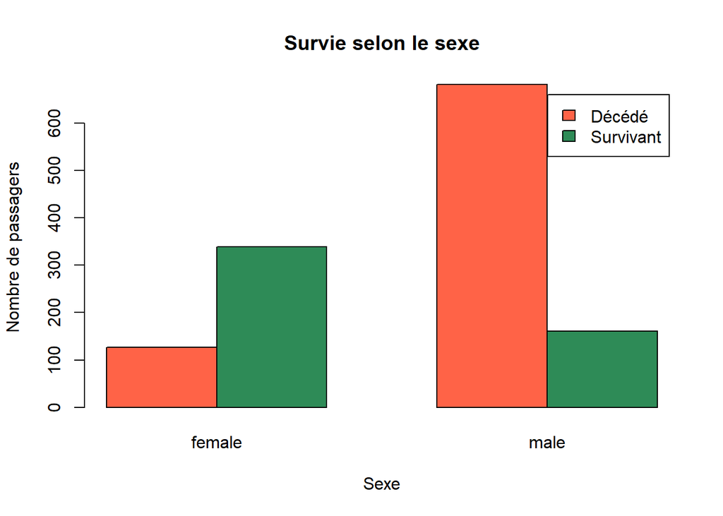

```r
barplot(t(tab_sexe), beside = TRUE,
        col = c("tomato", "seagreen"),
        legend.text = c("Décédé", "Survivant"),
        main = "Survie selon le sexe",
        xlab = "Sexe", ylab = "Nombre de passagers")
```

## 5. Survie selon la classe

```r
tab_classe <- table(TitanicSurvival$passengerClass, TitanicSurvival$survived)
tab_classe
```

```
##
##        no yes
##   1st 123 200
##   2nd 158 119
##   3rd 528 181
```

```r
round(prop.table(tab_classe, margin = 1) * 100, 1)  # % de survie par classe
```

```
##
##         no  yes
##   1st 38.1 61.9
##   2nd 57.0 43.0
##   3rd 74.5 25.5
```

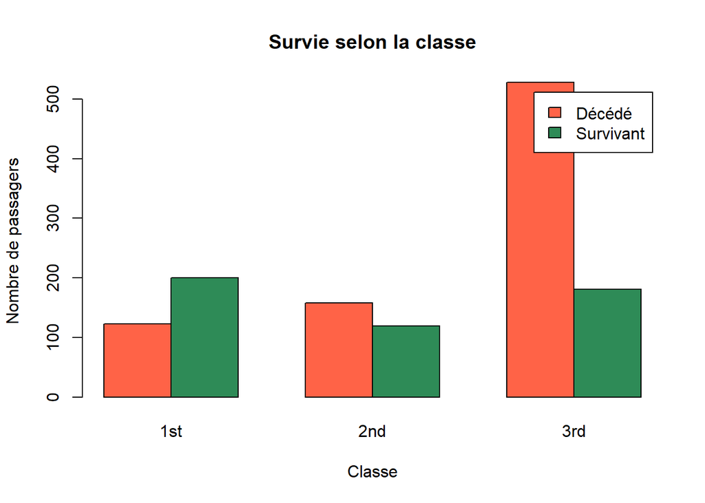

```r
barplot(t(tab_classe), beside = TRUE,
        col = c("tomato", "seagreen"),
        legend.text = c("Décédé", "Survivant"),
        main = "Survie selon la classe",
        xlab = "Classe", ylab = "Nombre de passagers")
```

## 6. Âge selon la survie

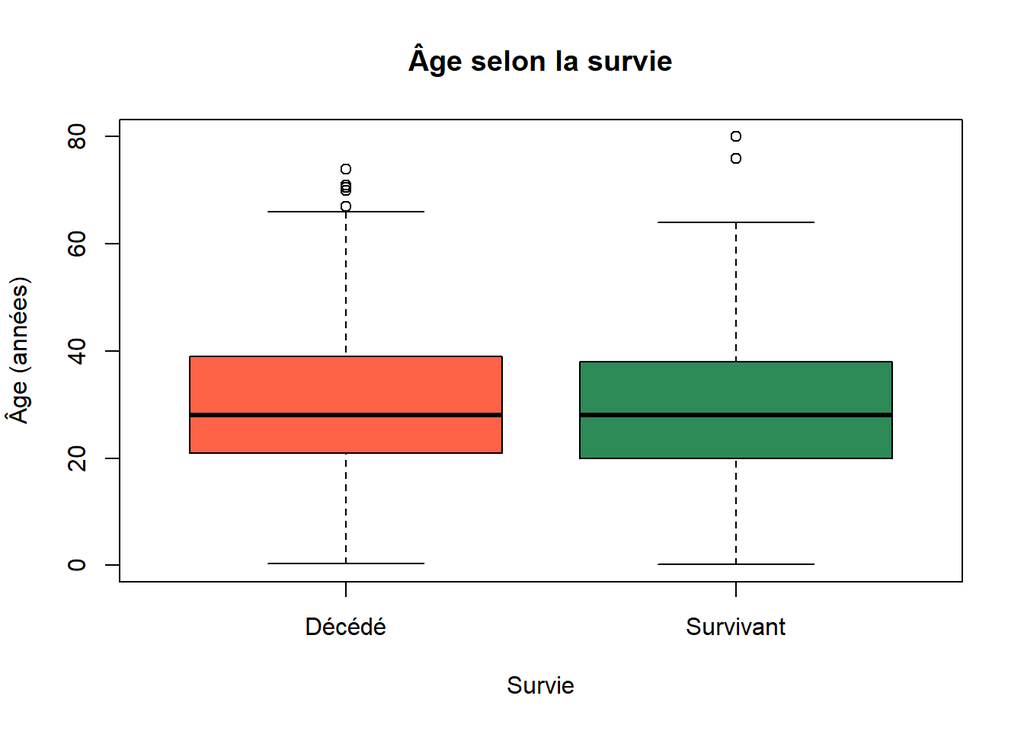

```r
boxplot(age ~ survived, data = TitanicSurvival,
        col = c("tomato", "seagreen"),
        names = c("Décédé", "Survivant"),
        main = "Âge selon la survie",
        xlab = "Survie", ylab = "Âge (années)")
```

```r
# Âge moyen et médian par groupe (sans les NA)
aggregate(age ~ survived, data = TitanicSurvival,
          FUN = function(x) c(moyenne = mean(x), mediane = median(x)))
```

```
##   survived age.moyenne age.mediane
## 1       no    30.54537    28.00000
## 2      yes    28.91823    28.00000
```

## 7. Interprétation

- **Survie globale** : environ 38 % des passagers ont survécu, la majorité a donc péri.
- **Sexe** : l’écart est très marqué. Environ 73 % des femmes ont survécu contre seulement 19 % des hommes, ce qui reflète la règle « les femmes et les enfants d’abord » appliquée lors de l’évacuation.
- **Classe** : la survie diminue avec la classe : environ 62 % en 1re classe, 43 % en 2e et 26 % en 3e. Les passagers de 1re classe étaient logés plus près des ponts et des canots, et ont été évacués en priorité.
- **Âge** : les distributions d’âge des survivants et des décédés sont assez proches ; les survivants sont légèrement plus jeunes en moyenne, en partie grâce à la priorité donnée aux enfants. L’âge semble donc moins déterminant que le sexe ou la classe. Attention : l’âge est manquant pour environ 20 % des passagers, ce qui limite cette conclusion.

**Conclusion** : le sexe et la classe sont les deux facteurs les plus liés à la survie. Être une femme voyageant en 1re classe maximisait les chances de survie, tandis qu’un homme de 3e classe avait les chances les plus faibles.

## 8. Utilisation du package test2026

La fonction `taux_survie()` de mon package `test2026` calcule directement le taux de survie (en %) selon une variable.

```r
library(test2026)
taux_survie(TitanicSurvival, "sex")
```

```
## # A tibble: 2 × 2
##   `data[, variable]` TauxSurvie
##   <fct>                   <dbl>
## 1 female                  0.727
## 2 male                    0.191
```

```r
taux_survie(TitanicSurvival, "passengerClass")
```

```
## # A tibble: 3 × 2
##   `data[, variable]` TauxSurvie
##   <fct>                   <dbl>
## 1 1st                     0.619
## 2 2nd                     0.430
## 3 3rd                     0.255
```

On retrouve les mêmes taux que dans les parties 4 et 5.